# Predicting Wine Quality with Regression Model

Prediction with Regression Model

Havva Nur Elveren

19 October 2021

# Objective: Predicting Wine Quality

Can we predict wine quality based on its features such as acidity, alcohol, sugar or sulfate level? In this project, we’ll predict Wine Quality with looking at the value of different features of a wine. We’ll use a data set that has been collected from red wine variants of the Portuguese “Vinho Verde” wine. If quality is greater than 6.5 it is considered as good wine, otherwise it is considered as bad wine.

# Data Description:

- 1.6K Row with 12 Column. You can download the data from the link https://www.kaggle.com/uciml/red-wine-quality-cortez-et-al-2009

```r
library(kableExtra)

dt <- data.frame(Name = c("fixed.acidity", "volatile.acidity", "citric.acid", "residual.sugar", "chlorides", "free.sulfur.dioxide", "total.sulfur.dioxide",
"density", "pH", "sulphates", "alcohol", "quality"),
Description = c("most acids involved with wine or fixed or nonvolatile (do not evaporate readily)", "the amount of acetic acid in wine, which at too high of levels can lead to an unpleasant, vinegar taste", "found in small quantities, citric acid can add 'freshness' and flavor to wines", "the amount of sugar remaining after fermentation stops, it's rare to find wines with less than 1 gram/liter and wines with greater than", "the amount of salt in the wine", "the free form of SO2 exists in equilibrium between molecular SO2 (as a dissolved gas) and bisulfite ion; it prevents", "amount of free and bound forms of S02; in low concentrations, SO2 is mostly undetectable in wine, but at free SO2", "the density of water is close to that of water depending on the percent alcohol and sugar content", "describes how acidic or basic a wine is on a scale from 0 (very acidic) to 14 (very basic); most wines are between 3-4 on the", "a wine additive which can contribute to sulfur dioxide gas (S02) levels, wich acts as an antimicrobial and", "the percent alcohol content of the wine","Score between 0 and 10, if quality > 6.5 it's Good, otherwise it is Bad "))

dt %>%
  kbl() %>%
  kable_styling()
```

[output not shown]

## Step 1: Load the Libraries

```r
library(tidyverse)
library(broom)
theme_set(theme_classic())

library(ISLR)
library(caret)
library(readxl)
library(pROC)
```

```r
library(lattice)
library(ggplot2)
library(dplyr)
library(e1071)
library(corrplot)
library(kknn)
library(ggplot2)
library(MLeval)
library(AppliedPredictiveModeling)
library(corrplot)
library(Hmisc)
library(dplyr)
library(ggfortify)
library(psych)
library(MASS)
```

## Step 2: Load the Data Set and Visualize the Relationships Among Features

```r
winedata <- read.csv("winequality-red.csv")
winedata <- data.frame(winedata, stringsAsFactors = FALSE)
str(winedata)
```

```
## 'data.frame':    1599 obs. of  12 variables:
##  $ fixed.acidity       : num  7.4 7.8 7.8 11.2 7.4 7.4 7.9 7.3 7.8 7.5 ...
##  $ volatile.acidity    : num  0.7 0.88 0.76 0.28 0.7 0.66 0.6 0.65 0.58 0.5 ...
##  $ citric.acid         : num  0 0 0.04 0.56 0 0 0.06 0 0.02 0.36 ...
##  $ residual.sugar      : num  1.9 2.6 2.3 1.9 1.9 1.8 1.6 1.2 2 6.1 ...
##  $ chlorides           : num  0.076 0.098 0.092 0.075 0.076 0.075 0.069 0.065 0.073 0.071 ...
##  $ free.sulfur.dioxide : num  11 25 15 17 11 13 15 15 9 17 ...
##  $ total.sulfur.dioxide: num  34 67 54 60 34 40 59 21 18 102 ...
##  $ density             : num  0.998 0.997 0.997 0.998 0.998 ...
##  $ pH                  : num  3.51 3.2 3.26 3.16 3.51 3.51 3.3 3.39 3.36 3.35 ...
##  $ sulphates           : num  0.56 0.68 0.65 0.58 0.56 0.56 0.46 0.47 0.57 0.8 ...
##  $ alcohol             : num  9.4 9.8 9.8 9.8 9.4 9.4 9.4 10 9.5 10.5 ...
##  $ quality             : int  5 5 5 6 5 5 5 7 7 5 ...
```

```r
table(winedata$quality)
```

```
##
##   3   4   5   6   7   8
##  10  53 681 638 199  18
```

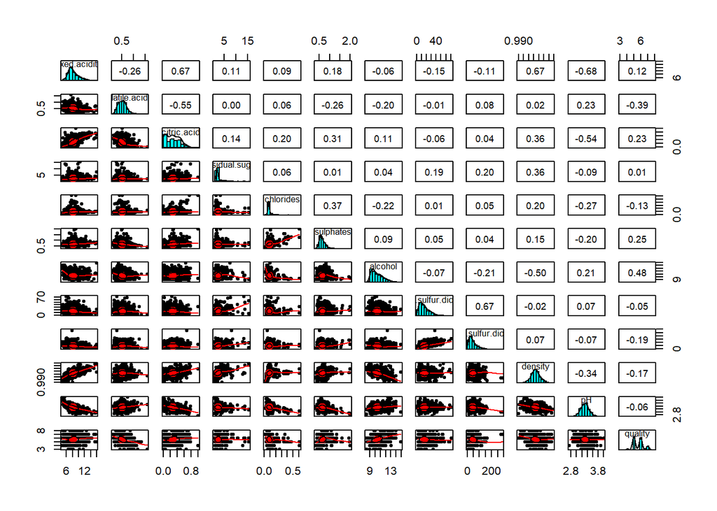

```r
#Visualize the correlation between features.
pairs.panels(winedata[c("fixed.acidity","volatile.acidity","citric.acid","residual.sugar","chlorides","sulphates", "alcohol","free.sulfur.dioxide","total.sulfur.dioxide","density","pH","quality")])
```

## Step 3: Prepare the Test and Training Data

```r
## Create random training and test data set with splitting the data with the proportion of %75 to %25.
trainIndex <- createDataPartition(winedata$quality, p = 0.75, list=FALSE)
trainData <- winedata[trainIndex,]
testData <- winedata[-trainIndex,]

prop.table(table(trainData$quality))
```

```
##
##           3           4           5           6           7           8
## 0.008333333 0.034166667 0.422500000 0.399166667 0.125833333 0.010000000
```

```r
prop.table((table(testData$quality)))
```

```
##
##          4          5          6          7          8
## 0.03007519 0.43609023 0.39849624 0.12030075 0.01503759
```